# Lead IQ Analysis- updated

Jinal Shah

2022-10-07

# Lead IQ data set description

Lead is highly poisonous if ingested directly, and affects almost every organ in the body. In low, indirect doses, the primary biological effect of lead exposure is damage to the nervous system. The maximum safe level of lead exposure, however, is somewhat controversial.

To investigate the relationship between low-level lead absorption and neurological function, a team of researchers led by the CDC investigated children between the ages of 3 and 15 in El Paso that lived various distances from a large, lead-emitting ore smelter. This data set contains a small portion of the data collected by the researchers. In particular, it should be noted that the primary comparison conducted by the researchers was between children with high lead levels and low lead levels, not between children who lived near and far from the smelter.

# A graph showing the IQ levels by location status

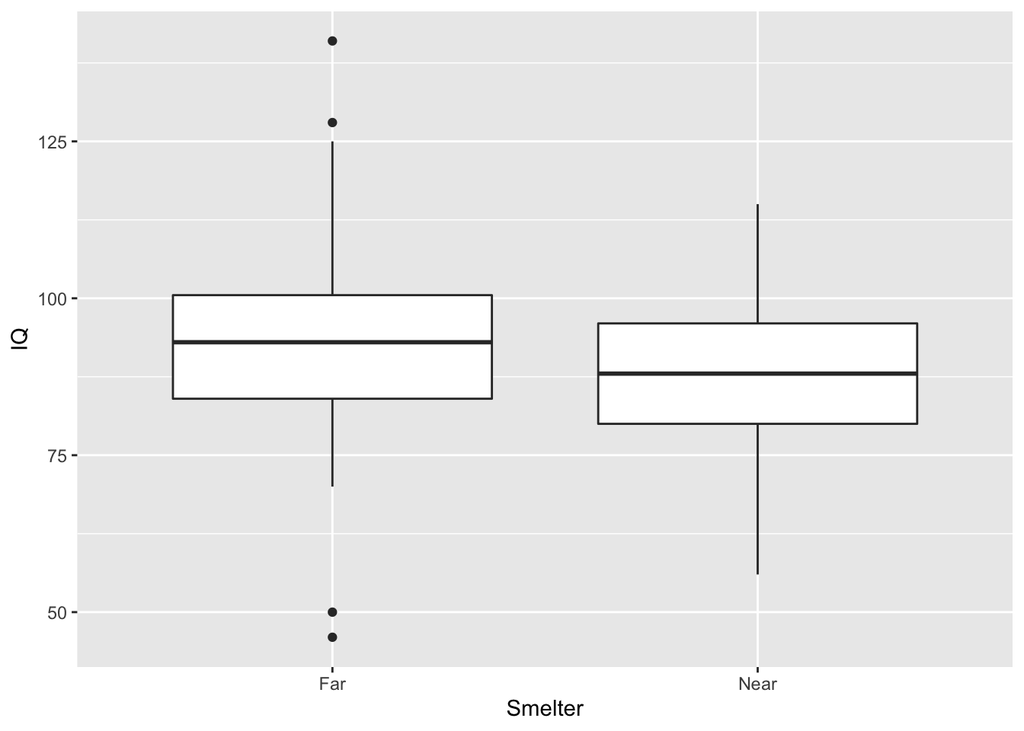

```r
# grouped boxplot
ggplot(lead_iq, aes(x=Smelter, y=IQ)) +
    geom_boxplot()
```

# B At least one nicely formatted table

```r
lead_iq_sum <- lead_iq%>%
  group_by(Smelter) %>%
  summarize(mean_IQ = round(mean(IQ, na.rm = TRUE),2),
            sd = round(sd (IQ, na.rm = T),2),
            median = median(IQ, na.rm = T),
            IQR = IQR(IQ, na.rm = T))

kable(x = lead_iq_sum,
      col.names = c("Distance from Smelter", "Mean IQ", "SD of IQ", "Median IQ", "IQR of IQ"),
      caption = "Summary statistics of IQ stratifed by Smelter") %>%
   kable_classic(full_width = FALSE, html_font = "Cambria", font_size=16)
```

Summary statistics of IQ stratifed by Smelter

| Distance from Smelter | Mean IQ | SD of IQ | Median IQ | IQR of IQ |
| --- | --- | --- | --- | --- |
| Far | 92.69 | 15.97 | 93 | 16.5 |
| Near | 89.19 | 12.17 | 88 | 16.0 |

# C & D Description of Graph and table

As seen from the boxplot above,after replacing the outliar value, the distribution of IQ in both group looks similar.The median IQ of far group is sightly higher than median IQ value for near group. There are still few outliers in group of children who live far from smear.

From the summary table above, we can see the summary statistics stratified by group. Mean IQ of group of children who lived far from lead smear had mean IQ of 92.69 compared to 89.19 IQ for children who lived near the smear.

# E At least one R code chunk.

There are two R chunks above in part A & B.